# Aflevering 7

Lucas Bagge

> se https://online.stat.psu.edu/stat415/lesson/26/26.1

## 8.42

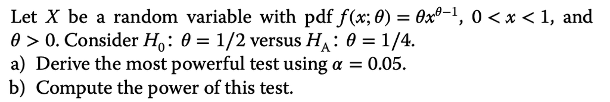

derive the most powerful test using alpha = 0.05

I opgaven har vi givet X med pdf $f(x;\theta)=\theta x^{\theta-1}$, hvor de respektive hypoteser er:

$$H_0:\theta=\frac{1}{2} \text{ og } H_1:\theta=\frac{1}{4}$$

### a)

I den første del af opgaven skal vi udlede **the most powerful test**, som er forholdsvis simple da vi det er simple hypoteser. Vi kan benytte os **Neyman Pearson** teorem 8.6.1, som fortæller os at forholdet mellem likelihoods skal være mindre end en konstant *k*. Da vi kun ser på en observation af X bliver det mere simpel:

$$\frac{L(\theta_0)}{L(\theta_\alpha)}=\frac{\frac{1}{2}x^{\frac{1}{2}-1}}{\frac{1}{4}x^{\frac{1}{4}-1}}$$
Det reduceres til:

$$=2x^{\frac{1}{4}}$$
Dermed er rejction regionen for the most powerful test:

$$2x^{\frac{1}{4}}\le k$$
Alternativ kan vi skrive, grundet $2x^\frac{1}{4}$ er en konstant, $k^*$ som en ny konstant

$$x <\frac{1}{16}k^4 = k^*$$

Nu skal vi finde k*, hvor vi gerne vil have

$$\alpha=\text{P(Type I error)}=\text{P(rejecting H0 when it is true)}$$

som skal være lig med 0.05. Dermed skal følgende holde:

$$\alpha=P(X< k^* \text{ når }\theta=\frac{1}{2})\\
= \int^{k^*}_0 \frac{1}{2}x^{\frac{1}{2}-1} \\
= [\sqrt{x}]^{k^*}_0 \\
= \sqrt{k^*} = 0.05$$
Hermed kan vi løse for k*

$$k^*=0.0025$$
Det vil sige at forkastning regionen af the most powerful test for

$$H_0:\theta=1/2\\
H_1:\theta=1/4$$
under fordeling funktionen er:

$$x< 0.0025$$

### b)

Herfra kan vi beregne power of the test:

$$\gamma=\int^{0.0025}_0 \frac{1}{4}x^{\frac{1}{4}-1}dx\\
= \frac{1}{2\cdot\sqrt{5}}\approx22.36 \%$$